# 6ABC WPVI Pennsylvania Vaccine Tracker

The 6ABC Action News Vaccine Tracker shows that about **8.6 million** people across Pennsylvania are fully vaccinated against COVID-19 as of Mar. 15. About **10.7 million** people statewide have received at least one dose.

Statewide, Action News' analysis shows the number of people fully vaccinated is about **67.3%** of all Pennsylvania residents.

| Fully vaccinated as a percentage of entire population |
| --- |
| 67.3 |

The data shows the share of Pennsylvania residents 12 or over who are now fully vaccinated is about **75.1%**. In May, the federal government approved the first vaccines for people ages 12-15, but it remains unavailable to children under 12.

| Fully vaccinated as a percentage of everyone 12 and older |
| --- |
| 75.1 |

You can search every vaccine provider with shots available today in Pennsylvania in our searchable map below.

## How is Pennsylvania doing getting everyone vaccinated?

You can see the percentage of all people vaccinated day-by-day in the chart below.

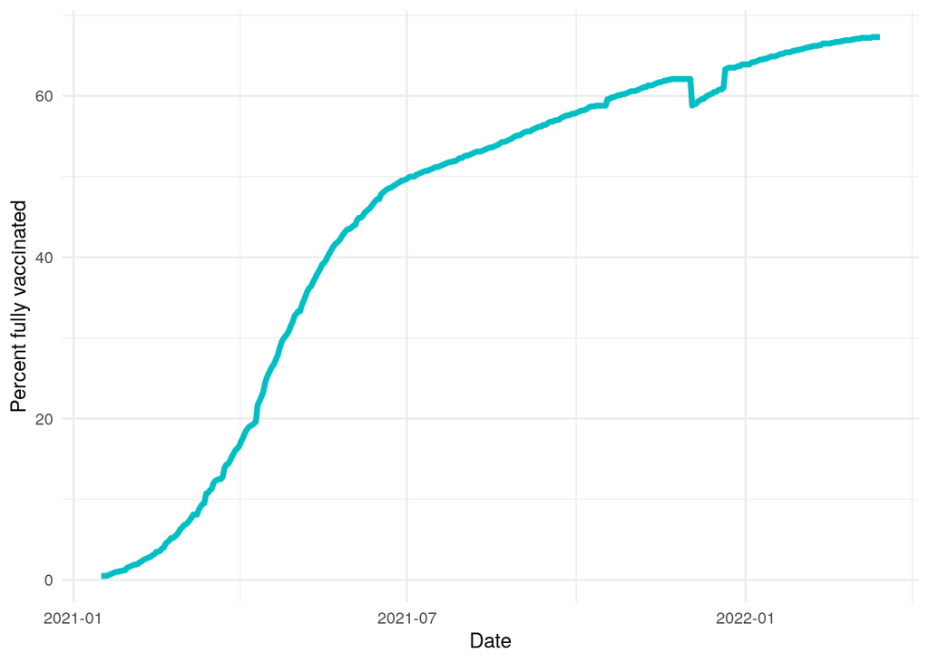

The CDC data is updated daily, but the agency says its total number of vaccinations could be behind actual doses administered by up to 72 hours based on when it receives data from state and local health departments.

## What's happening in my Pennsylvania county?

You can look up the progress thus far in **every Pennsylvania county** below. Start typing your county name in the search bar to find it faster. These county totals, from the CDC, include doses from state and federal government providers and only include the county's residents.

| County | Fully vaccinated | % of entire population | % of people 12 and over |
| --- | --- | --- | --- |
| Adams County | 56664 | 55 | 61.4 |
| Allegheny County | 838691 | 69 | 75.6 |
| Armstrong County | 38511 | 59.5 | 66.7 |
| Beaver County | 83499 | 50.9 | 56.7 |
| Bedford County | 18516 | 38.7 | 43.5 |
| Berks County | 251658 | 59.8 | 67.5 |
| Blair County | 63291 | 52 | 58.5 |
| Bradford County | 25601 | 42.4 | 48.6 |
| Bucks County | 448439 | 71.4 | 78.3 |
| Butler County | 119737 | 63.7 | 70.3 |

[output cut: 57 more lines]

## If I am eligible, where can I get vaccinated?

At least **2,598** pharmacies, medical facilities and other providers have vaccines in stock across Pennsylvania. You can **search all of them in our live map**, which pulls data every morning from the VaccineFinder system at the CDC's vaccines.gov.

The yellow and green circles show clusters of locations. If you click them, the map will zoom in to show individual locations. Clicking a red marker will show the vaccine location's name, address and ways to get more information online or by phone.

You can use the search button at top right to zoom to your address or zip code.

[interactive chart not shown]

Source: VaccineFinder, Boston Children's Hospital. Data ©2021. Boston Children’s Hospital. All rights reserved.

If you want to learn more about how state officials are administering vaccines, you can [click here](https://covid19.ncdhhs.gov/vaccines) (or scroll to the bottom to see a link) to learn more about the state's vaccination strategy.